# Tropical Cyclone Analysis

#### Change in counts of major storms

```
  SCUSUM Stat chpt Location       p-value
   0.38190334   17.00000000    0.08827739
```

The dates suggest the changepoint would occur from 1997 to 1998 with $p$-value 0.0882774.

In regime one, the mean number of storms is 10.6470588 (CI: 9.2036306, 12.3168634) and in regime two, the mean number of storms is 8.3703704 (CI: 7.3472126, 9.536011); a change of -2.2766885.

**Model Assessment**

The ratio of the residual deviance is 0.9555658.

The $p$-value for the Ljung-Box test on the deviance residuals 0.5852179.

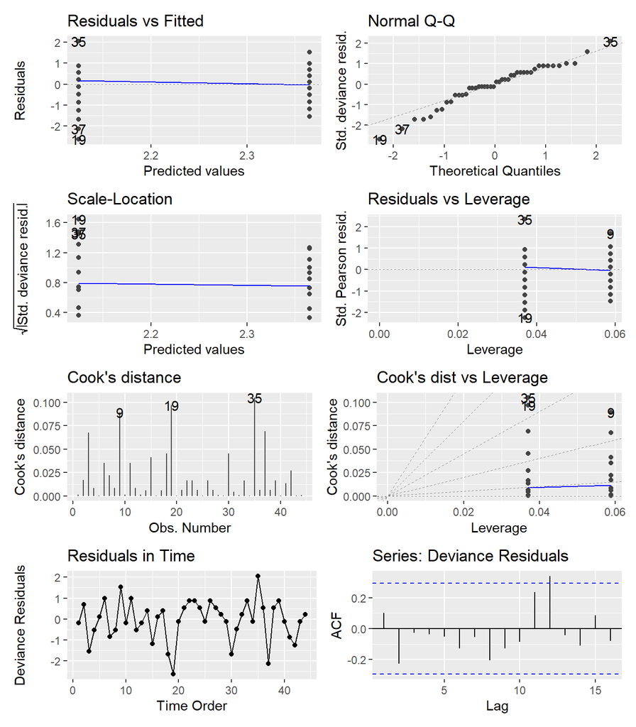

#### Change in counts of intense storms

```
  SCUSUM Stat chpt Location       p-value
   0.09652497   14.00000000    0.56292299
```

The dates suggest the changepoint would occur from 1994 to 1995 with $p$-value 0.562923.

In regime one, the mean number of storms is 7.2857143 (CI: 6.0005249, 8.8461648) and in regime two, the mean number of storms is 6 (CI: 5.184484, 6.9437961); a change of -1.2857143.

**Model Assessment**

The ratio of the residual deviance is 1.1999751.

The $p$-value for the Ljung-Box test on the deviance residuals 0.5193399.

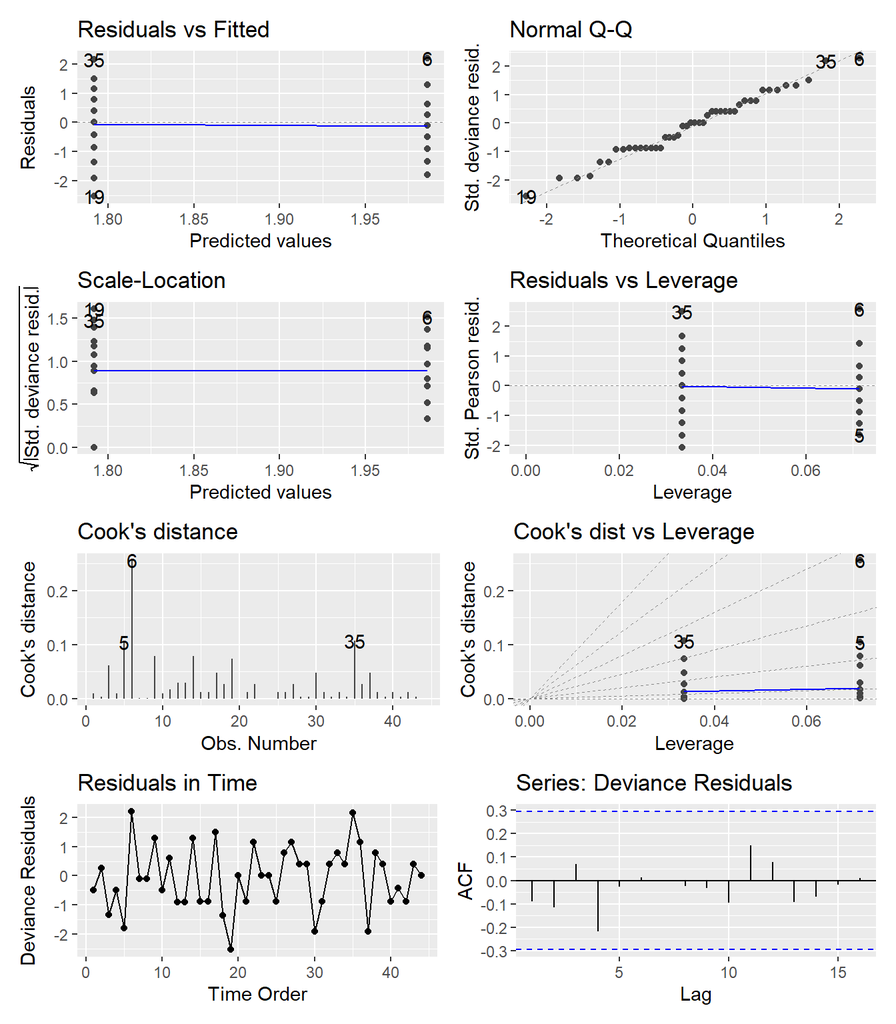

#### Proportion of major storms

A change in the proportion of major storms?

```
  SCUSUM Stat chpt Location       p-value
   0.05113116   42.00000000    0.86156267
```

The change in proportions occurs 2022 to 2023 with $p$-value 0.8615627.

In regime one, the proportion of major storms is 0.6055901 (CI: 0.5672841, 0.6426412) and in regime two, the proportion of major storms is 0.85 (CI: 0.6241502, 0.9508276); a change of 0.2444099.

**Model Assessment**

The ratio of the residual deviance is 0.9014895.

The $p$-value for the Ljung-Box test on the deviance residuals 0.456125.

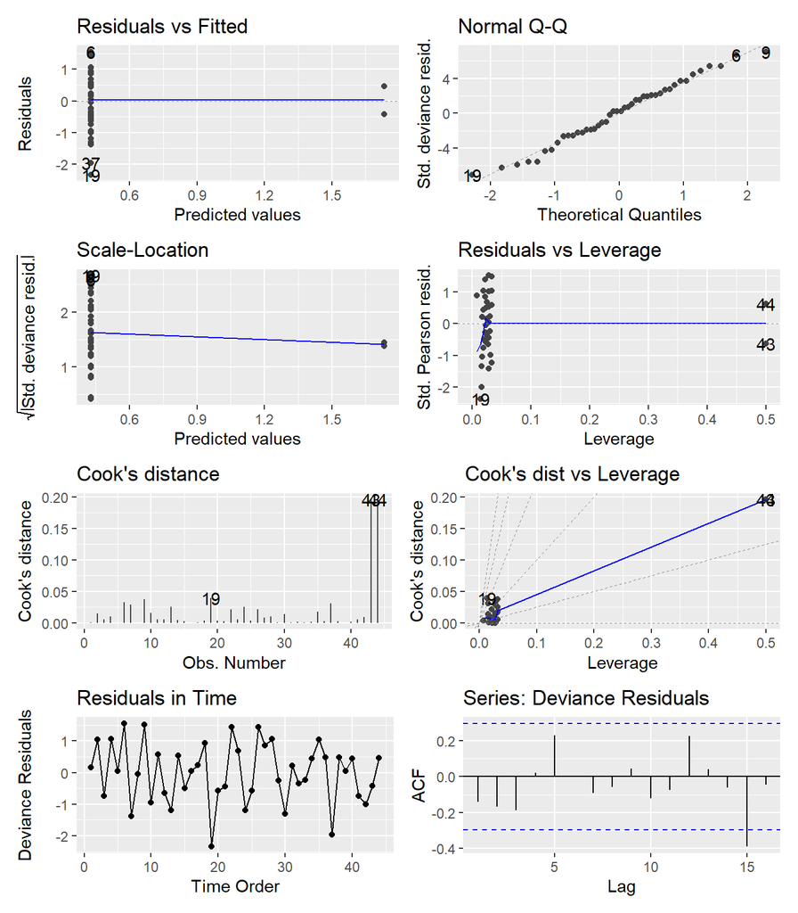

#### Proportion of intense storms

A change in the proportion of intense storms?

```
  SCUSUM Stat chpt Location       p-value
    0.2118048    25.0000000     0.2744140
```

The change in proportions occurs 2005 to 2006 with $p$-value 0.274414.

In regime one, the proportion of intense storms is 0.3897059 (CI: 0.3435491, 0.437927) and in regime two, the proportion of intense storms is 0.4804688 (CI: 0.4198591, 0.5416588); a change of 0.0907629.

**Model Assessment**

The ratio of the residual deviance is 1.4227698.

The $p$-value for the Ljung-Box test on the deviance residuals 0.4422821.

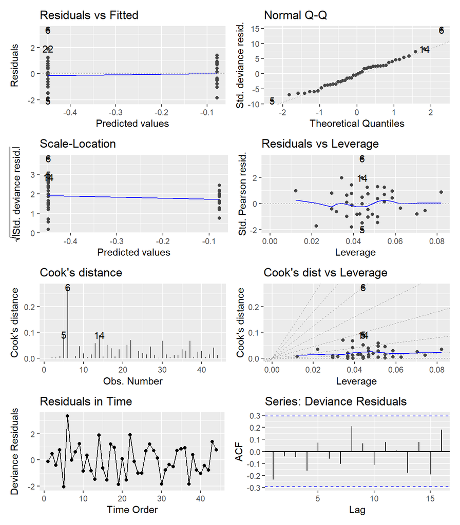

### Regression Methods

#### Poisson Regression on non-Shorties

```
Call:  glm(formula = Total_Storms ~ YearsSinceStart, family = poisson(link = "log"),
    data = storm_basin)

Coefficients:
    (Intercept)  YearsSinceStart
       2.873941        -0.007654

Degrees of Freedom: 43 Total (i.e. Null);  42 Residual
Null Deviance:      45.22
Residual Deviance: 38.97    AIC: 242.1
```

```
Single term deletions

Model:
Total_Storms ~ YearsSinceStart
                Df Deviance    AIC    LRT Pr(>Chi)
<none>               38.967 242.13
YearsSinceStart  1   45.222 246.38 6.2553  0.01238 *
---
Signif. codes:  0 '***' 0.001 '**' 0.01 '*' 0.05 '.' 0.1 ' ' 1
```

Using this model, in 1981 we would predict 17.7066584 storms (CI: 15.3387881, 20.4400601) and in 2024 we predict 12.740754 storms (CI: 10.8971479, 14.8962659).

That is a change of -1.1286146 storms per decade.

**Model Assessment**

The ratio of the residual deviance is 0.9277821.

The $p$-value for the Ljung-Box test on the deviance residuals 0.476691.

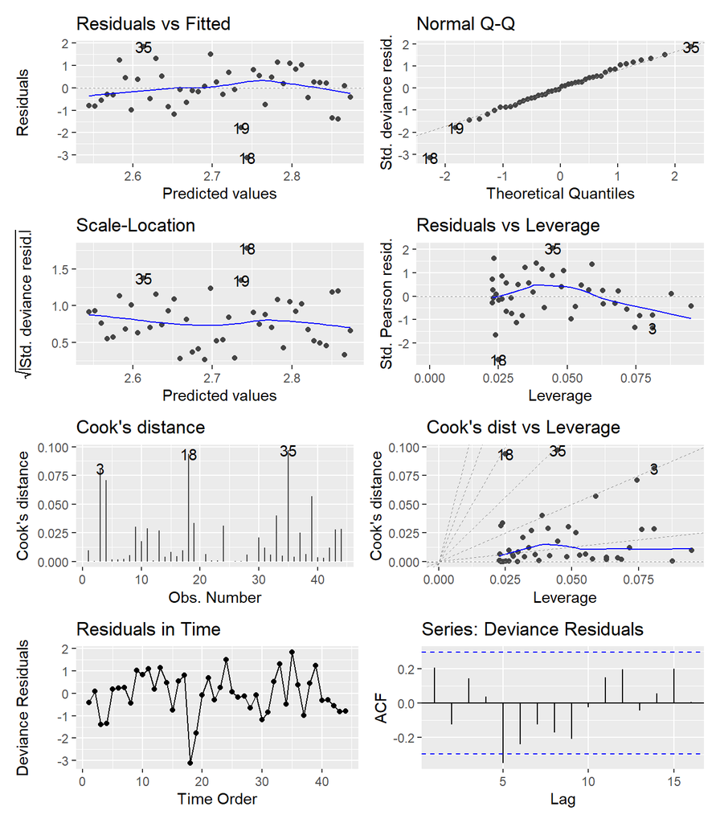

#### Poisson Regression on Hurricanes

```
Call:  glm(formula = Hurricanes ~ YearsSinceStart, family = poisson(link = "log"),
    data = storm_basin)

Coefficients:
    (Intercept)  YearsSinceStart
       2.616266        -0.006256

Degrees of Freedom: 43 Total (i.e. Null);  42 Residual
Null Deviance:      39.48
Residual Deviance: 36.16    AIC: 229.2
```

```
Single term deletions

Model:
Hurricanes ~ YearsSinceStart
                Df Deviance    AIC    LRT Pr(>Chi)
<none>               36.158 229.24
YearsSinceStart  1   39.484 230.57 3.3263  0.06818 .
---
Signif. codes:  0 '***' 0.001 '**' 0.01 '*' 0.05 '.' 0.1 ' ' 1
```

Using this model, in 1981 we would predict 13.6845281 hurricanes (CI: 11.6360298, 16.0936601) and in 2024 we predict 10.4566657 hurricanes (CI: 8.7881096, 12.4420226).

That is a change of -0.7336051 hurricanes per decade.

**Model Assessment**

The ratio of the residual deviance is 0.8609091.

The $p$-value for the Ljung-Box test on the deviance residuals 0.2934022.

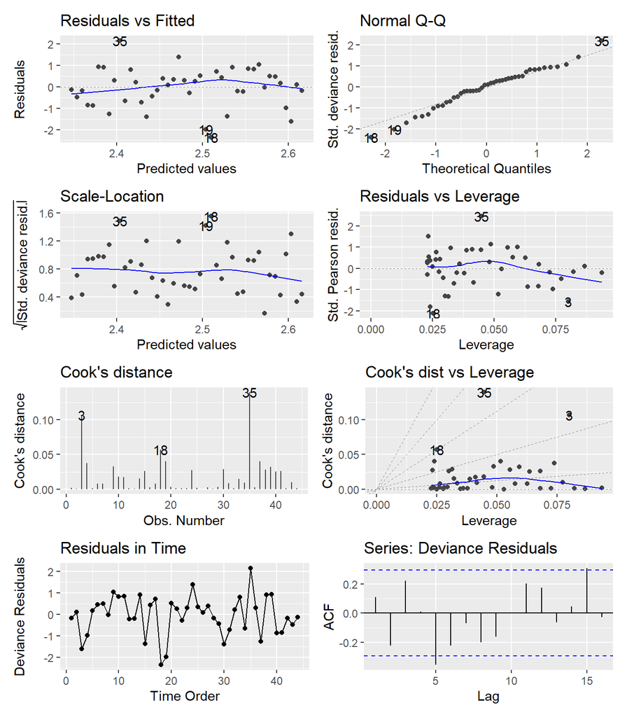

#### Poisson Regression on Major Storms

```
Call:  glm(formula = Major_Storms ~ YearsSinceStart, family = poisson(link = "log"),
    data = storm_basin)

Coefficients:
    (Intercept)  YearsSinceStart
       2.376419        -0.007258

Degrees of Freedom: 43 Total (i.e. Null);  42 Residual
Null Deviance:      45.89
Residual Deviance: 42.44    AIC: 223.1
```

```
Single term deletions

Model:
Major_Storms ~ YearsSinceStart
                Df Deviance    AIC    LRT Pr(>Chi)
<none>               42.438 223.13
YearsSinceStart  1   45.886 224.58 3.4481  0.06333 .
---
Signif. codes:  0 '***' 0.001 '**' 0.01 '*' 0.05 '.' 0.1 ' ' 1
```

Using this model, in 1981 we would predict 10.7662803 major storms (CI: 8.9592029, 12.9378463) and in 2024 we predict 7.8801091 major storms (CI: 6.4570094, 9.6168544).

That is a change of -0.655948 major storms per decade.

**Model Assessment**

The ratio of the residual deviance is 1.0104376.

The $p$-value for the Ljung-Box test on the deviance residuals 0.4913286.

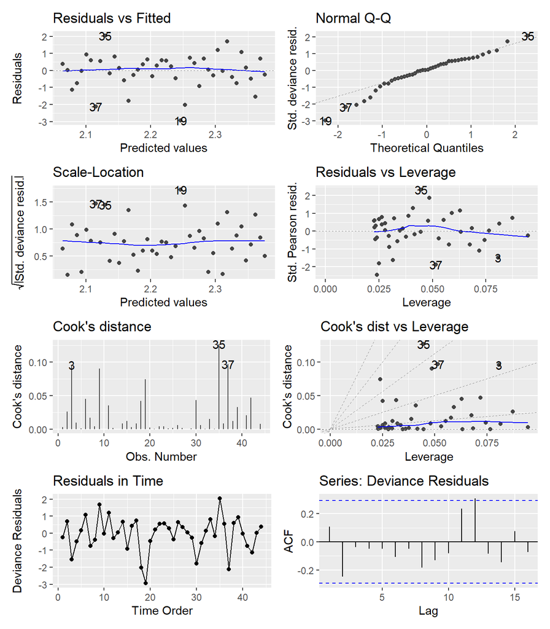

#### Poisson Regression on Intense Storms

```
Call:  glm(formula = Intense_Storms ~ YearsSinceStart, family = poisson(link = "log"),
    data = storm_basin)

Coefficients:
    (Intercept)  YearsSinceStart
       1.924091        -0.003124

Degrees of Freedom: 43 Total (i.e. Null);  42 Residual
Null Deviance:      52.81
Residual Deviance: 52.36    AIC: 215.7
```

```
Single term deletions

Model:
Intense_Storms ~ YearsSinceStart
                Df Deviance    AIC    LRT Pr(>Chi)
<none>               52.363 215.66
YearsSinceStart  1   52.806 214.10 0.4435   0.5054
```

Using this model, in 1981 we would predict 6.8489233 intense storms (CI: 5.4656244, 8.5823225) and in 2024 we predict 5.9880763 intense storms (CI: 4.7406868, 7.5636842).

That is a change of -0.1956471 intense storms per decade.

**Model Assessment**

The ratio of the residual deviance is 1.2467377.

The $p$-value for the Ljung-Box test on the deviance residuals 0.6048463.

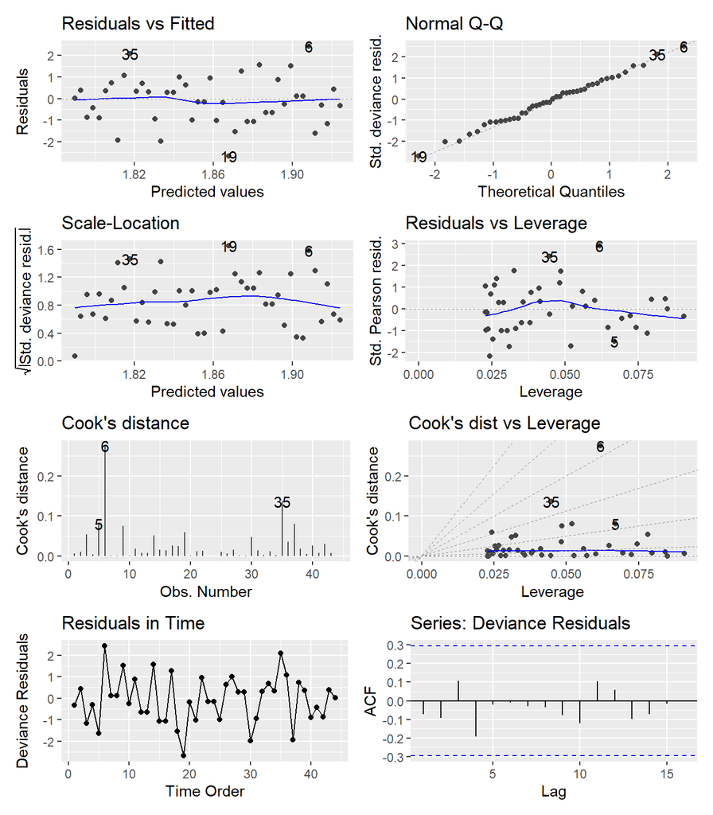

#### Logistic Regression on Proportions of Major

```
Call:  glm(formula = cbind(Major_Storms, Non_Major) ~ YearsSinceStart,
    family = binomial, data = prop_data)

Coefficients:
    (Intercept)  YearsSinceStart
       0.438312         0.001058

Degrees of Freedom: 43 Total (i.e. Null);  42 Residual
Null Deviance:      43.44
Residual Deviance: 43.41    AIC: 180.5
```

```
Single term deletions

Model:
cbind(Major_Storms, Non_Major) ~ YearsSinceStart
                Df Deviance    AIC      LRT Pr(>Chi)
<none>               43.411 180.54
YearsSinceStart  1   43.438 178.56 0.027397   0.8685
```

Using this model, in 1981 the probability of a major storm in was 0.6078566 (CI: 0.5350853, 0.6761317) and in 2024 the probability of a major storm was 0.6186469 (CI: 0.5395582, 0.6919078).

That is a change of 0.245233 percent per decade.

**Model Assessment**

The ratio of the residual deviance is 1.0335895.

The $p$-value for the Ljung-Box test on the deviance residuals 0.447345.

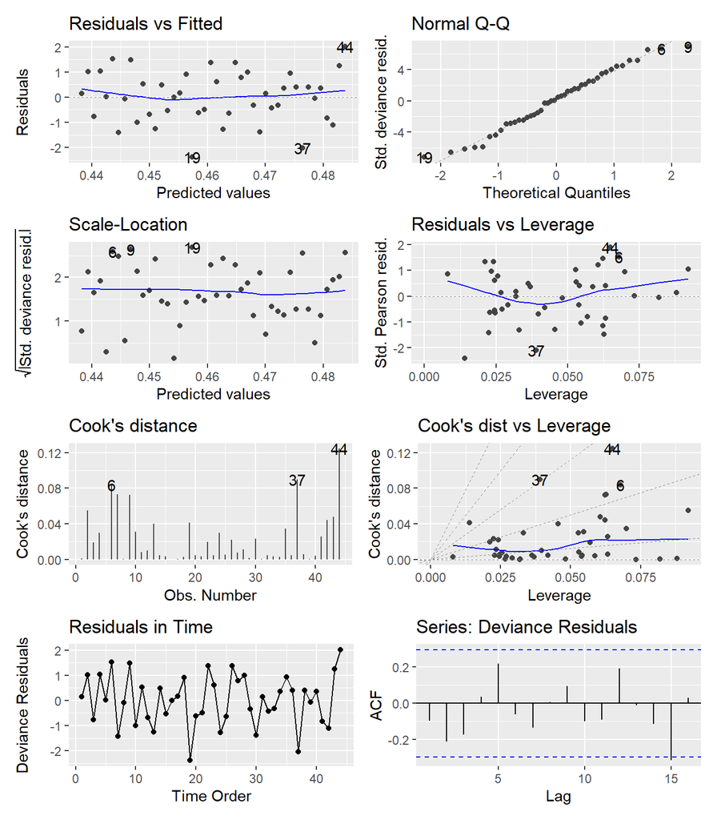

#### Logistic Regression on Proportions of Intense

```
Call:  glm(formula = cbind(Intense_Storms, Non_Intense) ~ YearsSinceStart,
    family = binomial, data = prop_data)

Coefficients:
    (Intercept)  YearsSinceStart
      -0.469530         0.008153

Degrees of Freedom: 43 Total (i.e. Null);  42 Residual
Null Deviance:      65.05
Residual Deviance: 63.37    AIC: 200.8
```

```
Single term deletions

Model:
cbind(Intense_Storms, Non_Intense) ~ YearsSinceStart
                Df Deviance    AIC    LRT Pr(>Chi)
<none>               63.373 200.79
YearsSinceStart  1   65.047 200.46 1.6739   0.1957
```

**Model Assessment**

The ratio of the residual deviance is 1.5088723.

The $p$-value for the Ljung-Box test on the deviance residuals 0.5999425.

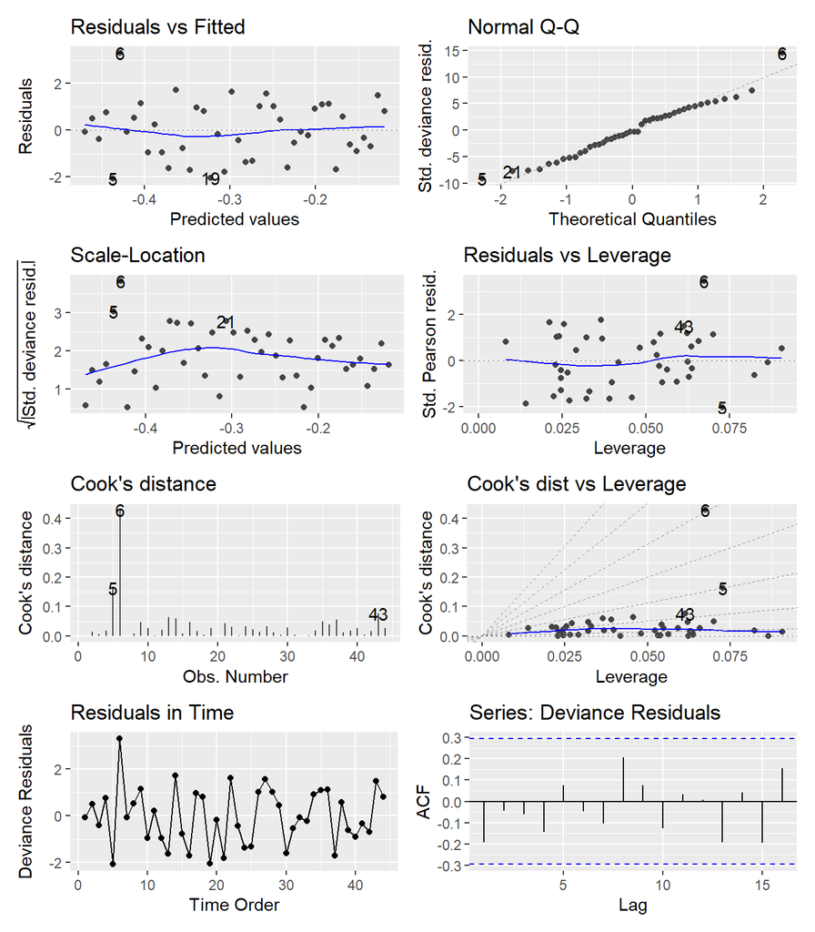

# North Indian

## IBTrACS Quick Results

### Summary Statistics and Data

| Total Storms (Avg) | Total Storms (stddev) | Hurricanes (Avg) | Hurricanes (stddev) | Major Storms (Avg) | Major Storms (stddev) | Prop Major Storms | Intense Storms (Avg) | Intense Storms (stddev) | Prop Intense Storms |
| --- | --- | --- | --- | --- | --- | --- | --- | --- | --- |
| 1.869565 | 1.408051 | 1.347826 | 1.177896 | 0.7608696 | 0.9233943 | 0.4069767 | 0.4782609 | 0.6579136 | 0.255814 |

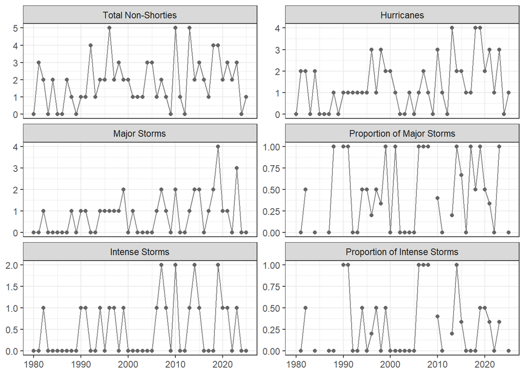

### Testing Results

**Changepoint Methods**

Here, we report the estimate mean for each segment or regime regardless of whether the test found a significant shift.

| Response | Chpt.Location | p.value | Regime1 | Regime2 | Change | Perc_Change |
| --- | --- | --- | --- | --- | --- | --- |
| Cyclone Freq | 1993 | 0.10439 | 1.00000 | 2.17647 | 1.17647 | 117.6471 |
| Hurricanes | 2014 | 0.01978 | 1.03030 | 2.15385 | 1.12354 | 109.0498 |
| Major Freq | 2007 | 0.01243 | 0.46154 | 1.15000 | 0.68846 | 149.1667 |
| Prop Major | 1989 | 0.22610 | 11.11111 | 44.15584 | 33.04473 | 297.4026 |
| Intense Freq | 2007 | 0.11768 | 0.26923 | 0.75000 | 0.48077 | 178.5714 |
| Prop Freq | 2007 | 0.48112 | 15.90909 | 35.71429 | 19.80519 | 124.4898 |

**Generalized Linear Model Approaches**

Note:

- we report the Likelihood Ratio Test for the generalized linear models, this is better to use than the default $Z$-test provided in the `summary()` output.
- the Change per decade is found by comparing the predicted value at the start time (1980) and end time (2025) and scaling by the number of years $\times 10$.

| Response | Coefficent | p.value | Start | End | Change per Decade |
| --- | --- | --- | --- | --- | --- |
| Cyclone Freq | 0.01368 | 0.09375 | 1.35184 | 2.50195 | 0.25002 |
| Hurricanes | 0.02264 | 0.01955 | 0.77447 | 2.14483 | 0.29790 |
| Major Freq | 0.03379 | 0.00995 | 0.32231 | 1.47449 | 0.25047 |
| Prop Major | 0.03862 | 0.03570 | 20.41382 | 59.32602 | 8.45917 |
| Intense Freq | 0.02642 | 0.10619 | 0.24838 | 0.81550 | 0.12329 |
| Prop Freq | 0.01942 | 0.34014 | 17.28952 | 33.36954 | 3.49566 |

## IBTrACS Full Analysis

### Changepoint Methods

#### Change in Non-Shorty Counts

```
  SCUSUM Stat chpt Location       p-value
    0.3552556    12.0000000     0.1043917
```

The dates suggest the changepoint would occur from 1992 to 1993 with $p$-value 0.1043917.

In regime one, the mean number of storms is 1 (CI: 0.5679052, 1.7608572) and in regime two, the mean number of storms is 2.1764706 (CI: 1.733009, 2.7334101); a change of 1.1764706.

**Model Assessment**

The ratio of the residual deviance is 1.1054385.

The $p$-value for the Ljung-Box test on the deviance residuals 0.1797535.

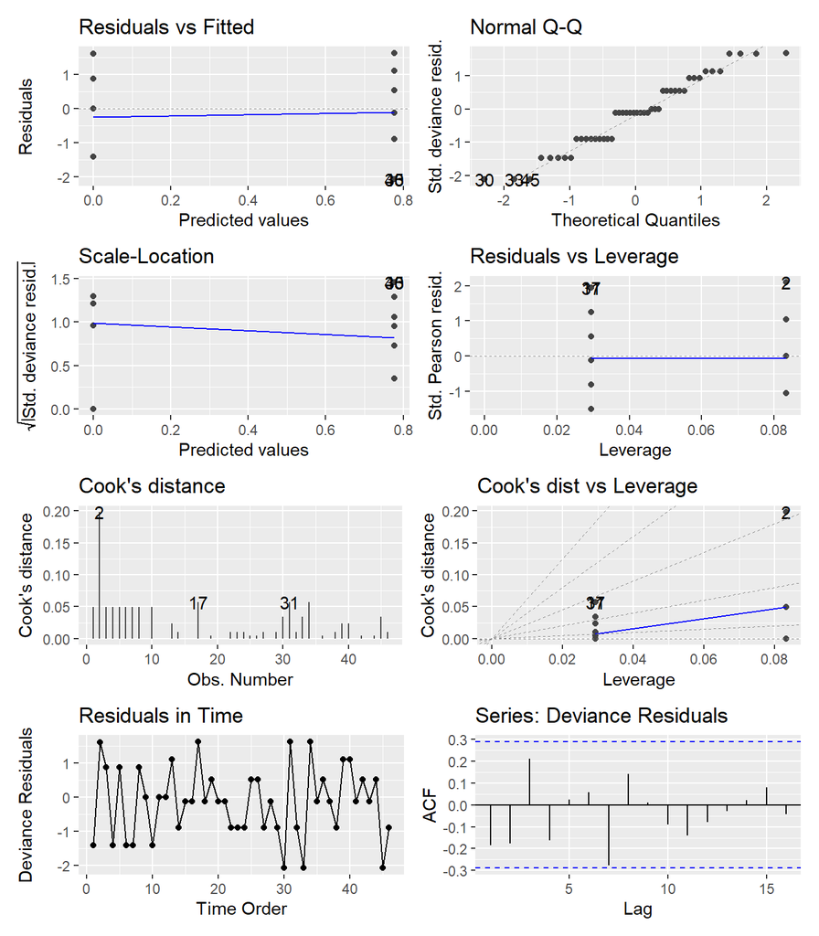

#### Change in counts of hurricanes

```
  SCUSUM Stat chpt Location       p-value
   0.63371242   33.00000000    0.01977942
```

The dates suggest the changepoint would occur from 2013 to 2014 with $p$-value 0.0197794.

In regime one, the mean number of hurricanes is 1.030303 (CI: 0.7361776, 1.4419406) and in regime two, the mean number of hurricanes is 2.1538462 (CI: 1.4871328, 3.1194613); a change of 1.1235431.

**Model Assessment**

The ratio of the residual deviance is 1.0496919.

The $p$-value for the Ljung-Box test on the deviance residuals 0.7815422.

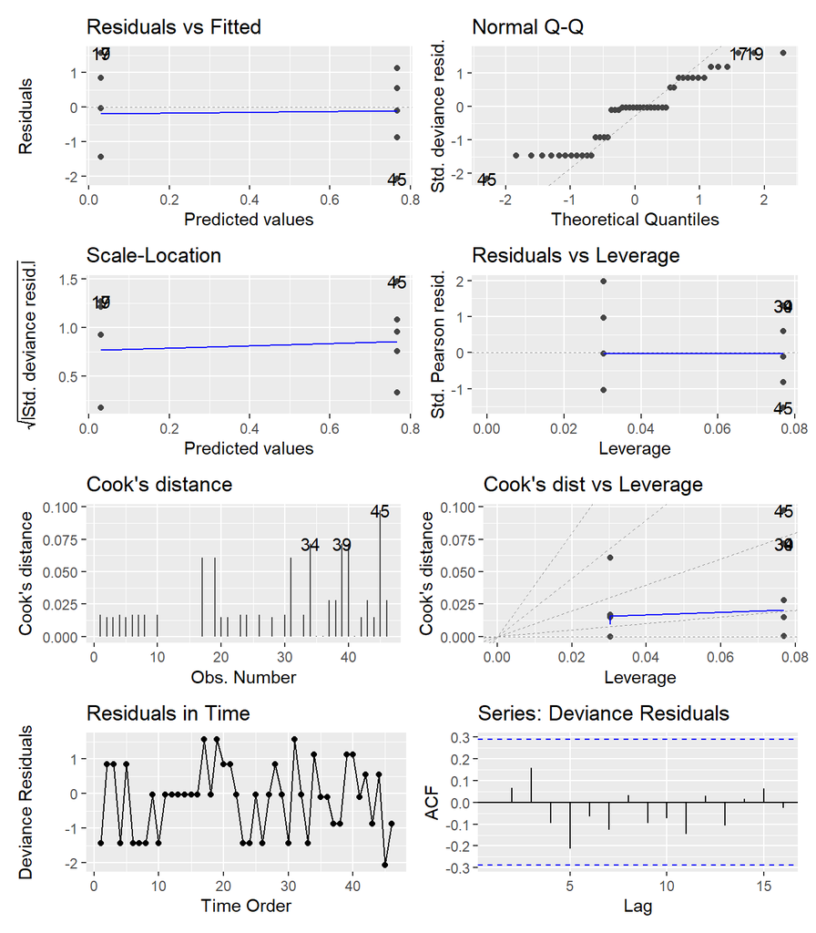

#### Change in counts of major storms

```
  SCUSUM Stat chpt Location       p-value
   0.71556171   26.00000000    0.01242855
```

The dates suggest the changepoint would occur from 2006 to 2007 with $p$-value 0.0124285.

In regime one, the mean number of storms is 0.4615385 (CI: 0.2621113, 0.8126996) and in regime two, the mean number of storms is 1.15 (CI: 0.7642003, 1.7305673); a change of 0.6884615.

**Model Assessment**

The ratio of the residual deviance is 1.0555697.

The $p$-value for the Ljung-Box test on the deviance residuals 0.9322326.

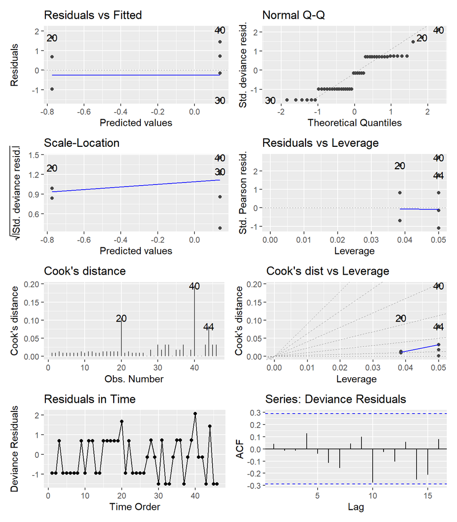

#### Change in counts of intense storms

```
  SCUSUM Stat chpt Location       p-value
    0.3364839    26.0000000     0.1176752
```

The dates suggest the changepoint would occur from 2006 to 2007 with $p$-value 0.1176752.

In regime one, the mean number of storms is 0.2692308 (CI: 0.128355, 0.5647246) and in regime two, the mean number of storms is 0.75 (CI: 0.4521461, 1.2440669); a change of 0.4807692.

**Model Assessment**

The ratio of the residual deviance is 0.8657142.

The $p$-value for the Ljung-Box test on the deviance residuals 0.7410037.

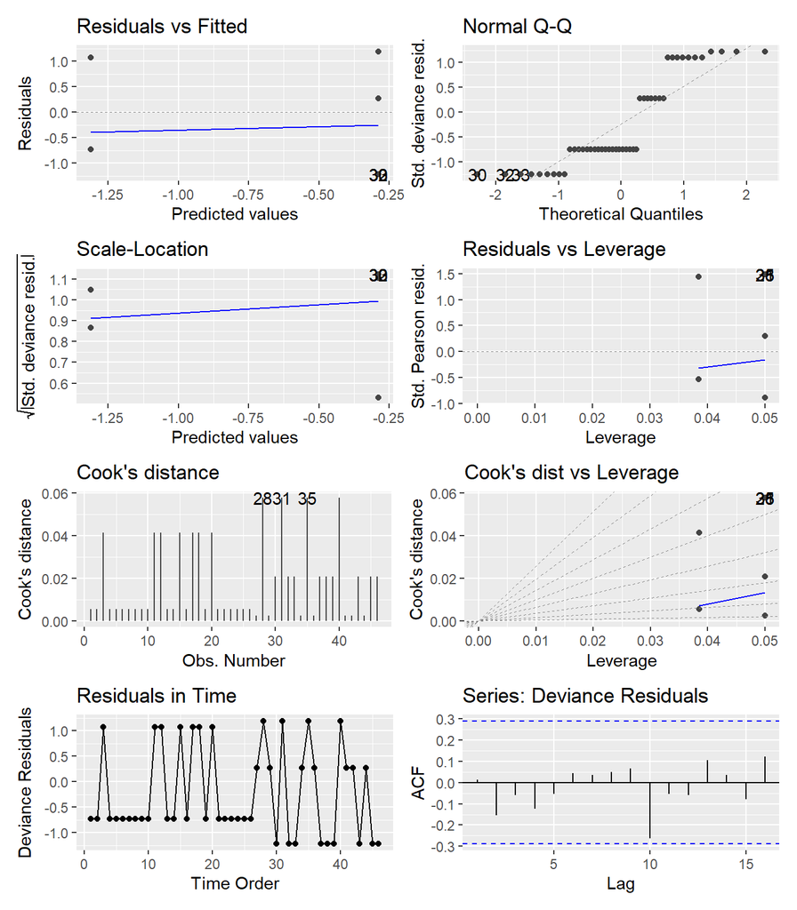

#### Proportion of major storms

A change in the proportion of major storms?

```
  SCUSUM Stat chpt Location       p-value
    0.2388649     8.0000000     0.2261018
```

The change in proportions occurs 1988 to 1989 with $p$-value 0.2261018.

In regime one, the proportion of major storms is 0.1111111 (CI: 0.0153943, 0.4998406) and in regime two, the proportion of major storms is 0.4415584 (CI: 0.3352247, 0.5535362); a change of 0.3304473.

**Model Assessment**

The ratio of the residual deviance is 1.7879374.

The $p$-value for the Ljung-Box test on the deviance residuals 0.6062406.

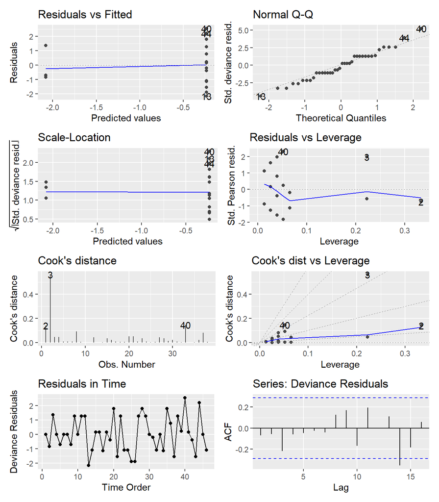

#### Proportion of intense storms

A change in the proportion of intense storms?

```
  SCUSUM Stat chpt Location       p-value
    0.1399852    26.0000000     0.4811205
```

The change in proportions occurs 2006 to 2007 with $p$-value 0.4811205.

In regime one, the proportion of intense storms is 0.1590909 (CI: 0.0777828, 0.297934) and in regime two, the proportion of intense storms is 0.3571429 (CI: 0.2281184, 0.5108466); a change of 0.1980519.

**Model Assessment**

The ratio of the residual deviance is 1.2695008.

The $p$-value for the Ljung-Box test on the deviance residuals 0.5065725.

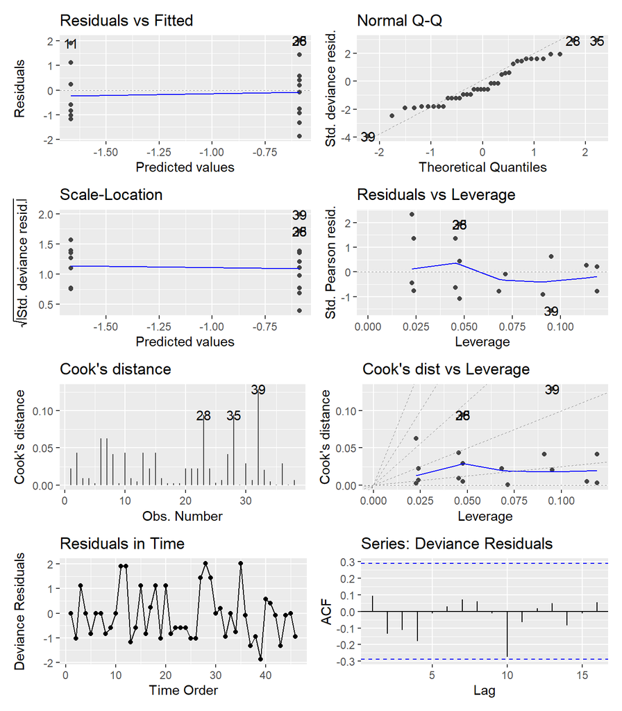

### Regression Methods

#### Poisson Regression on non-Shorties

```
Call:  glm(formula = Total_Storms ~ YearsSinceStart, family = poisson(link = "log"),
    data = storm_basin)

Coefficients:
    (Intercept)  YearsSinceStart
        0.30147          0.01368

Degrees of Freedom: 45 Total (i.e. Null);  44 Residual
Null Deviance:      56.12
Residual Deviance: 53.31    AIC: 156.5
```

```
Single term deletions

Model:
Total_Storms ~ YearsSinceStart
                Df Deviance    AIC    LRT Pr(>Chi)
<none>               53.309 156.47
YearsSinceStart  1   56.118 157.28 2.8089  0.09375 .
---
Signif. codes:  0 '***' 0.001 '**' 0.01 '*' 0.05 '.' 0.1 ' ' 1
```

Using this model, in 1980 we would predict 1.3518379 storms (CI: 0.8597058, 2.1256874) and in 2025 we predict 2.5019502 storms (CI: 1.7004145, 3.6813111).

That is a change of 0.2500244 storms per decade.

**Model Assessment**

The ratio of the residual deviance is 1.211575.

The $p$-value for the Ljung-Box test on the deviance residuals 0.4647557.

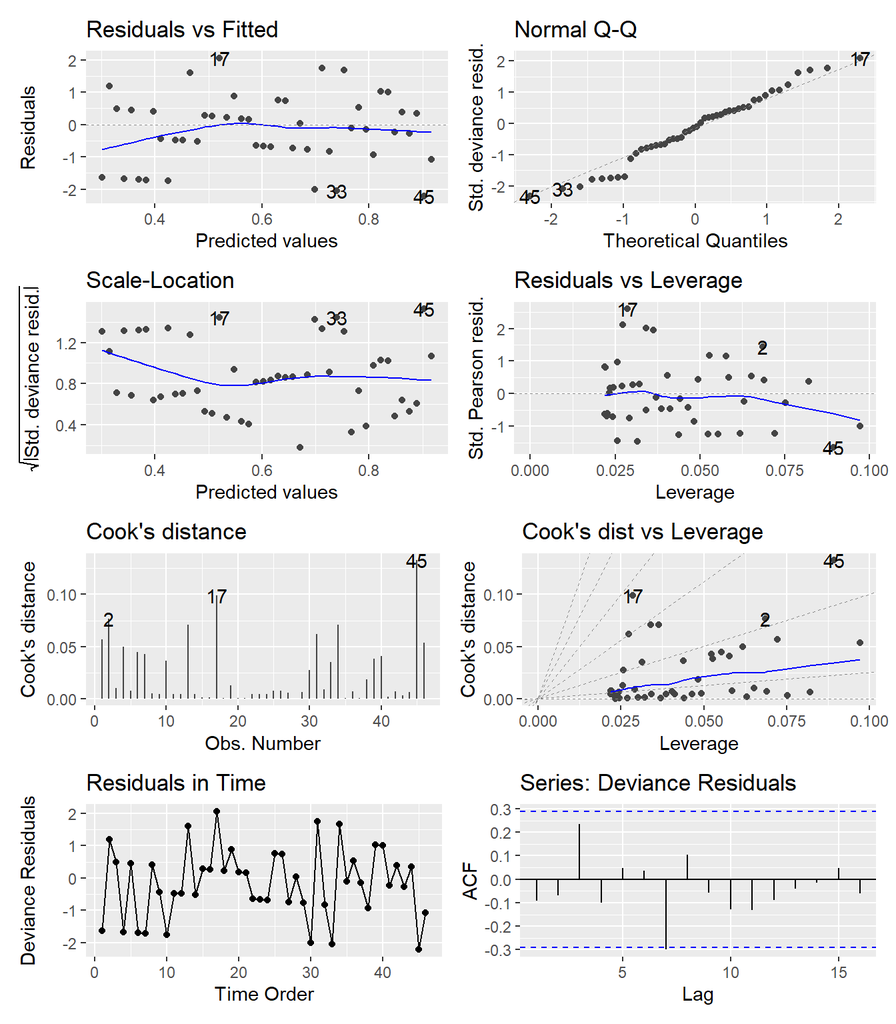

#### Poisson Regression on Hurricanes

```
Call:  glm(formula = Hurricanes ~ YearsSinceStart, family = poisson(link = "log"),
    data = storm_basin)

Coefficients:
    (Intercept)  YearsSinceStart
       -0.25558          0.02264

Degrees of Freedom: 45 Total (i.e. Null);  44 Residual
Null Deviance:      54.17
Residual Deviance: 48.72    AIC: 135
```

```
Single term deletions

Model:
Hurricanes ~ YearsSinceStart
                Df Deviance    AIC    LRT Pr(>Chi)
<none>               48.718 135.00
YearsSinceStart  1   54.170 138.45 5.4517  0.01955 *
---
Signif. codes:  0 '***' 0.001 '**' 0.01 '*' 0.05 '.' 0.1 ' ' 1
```

Using this model, in 1980 we would predict 0.7744659 hurricanes (CI: 0.4395649, 1.3645252) and in 2025 we predict 2.1448256 hurricanes (CI: 1.3870544, 3.3165802).

That is a change of 0.2979043 hurricanes per decade.

**Model Assessment**

The ratio of the residual deviance is 1.1072244.

The $p$-value for the Ljung-Box test on the deviance residuals 0.7986087.

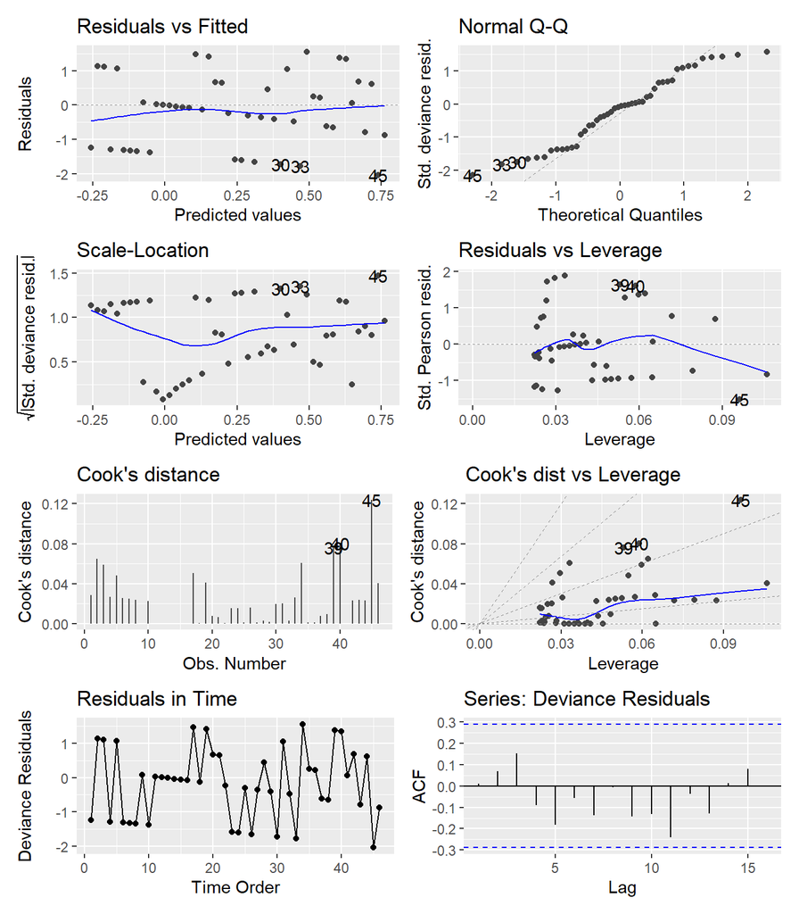

#### Poisson Regression on Major Storms

```
Call:  glm(formula = Major_Storms ~ YearsSinceStart, family = poisson(link = "log"),
    data = storm_basin)

Coefficients:
    (Intercept)  YearsSinceStart
       -1.13223          0.03379

Degrees of Freedom: 45 Total (i.e. Null);  44 Residual
Null Deviance:      53.45
Residual Deviance: 46.8     AIC: 104.7
```

```
Single term deletions

Model:
Major_Storms ~ YearsSinceStart
                Df Deviance    AIC    LRT Pr(>Chi)
<none>               46.805 104.75
YearsSinceStart  1   53.448 109.39 6.6432 0.009954 **
---
Signif. codes:  0 '***' 0.001 '**' 0.01 '*' 0.05 '.' 0.1 ' ' 1
```

Using this model, in 1980 we would predict 0.3223132 major storms (CI: 0.1423876, 0.7295986) and in 2025 we predict 1.4744937 major storms (CI: 0.8475444, 2.5652125).

That is a change of 0.250474 major storms per decade.

**Model Assessment**

The ratio of the residual deviance is 1.0637477.

The $p$-value for the Ljung-Box test on the deviance residuals 0.9467366.

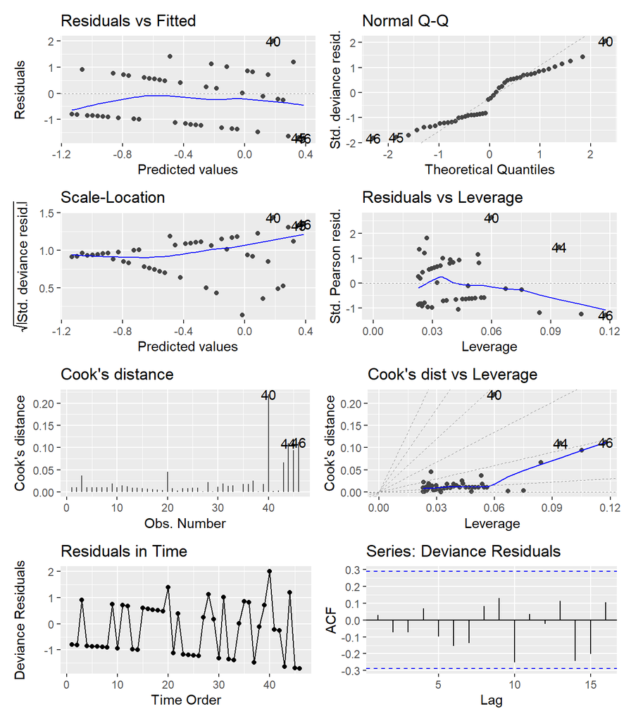

#### Poisson Regression on Intense Storms

```
Call:  glm(formula = Intense_Storms ~ YearsSinceStart, family = poisson(link = "log"),
    data = storm_basin)

Coefficients:
    (Intercept)  YearsSinceStart
       -1.39278          0.02642

Degrees of Freedom: 45 Total (i.e. Null);  44 Residual
Null Deviance:      43.54
Residual Deviance: 40.93    AIC: 83.39
```

```
Single term deletions

Model:
Intense_Storms ~ YearsSinceStart
                Df Deviance   AIC  LRT Pr(>Chi)
<none>               40.935 83.39
YearsSinceStart  1   43.545 84.00 2.61   0.1062
```

Using this model, in 1980 we would predict 0.2483849 intense storms (CI: 0.0935462, 0.6595141) and in 2025 we predict 0.8155017 intense storms (CI: 0.3970762, 1.6748496).

That is a change of 0.1232863 intense storms per decade.

**Model Assessment**

The ratio of the residual deviance is 0.9303341.

The $p$-value for the Ljung-Box test on the deviance residuals 0.7158725.

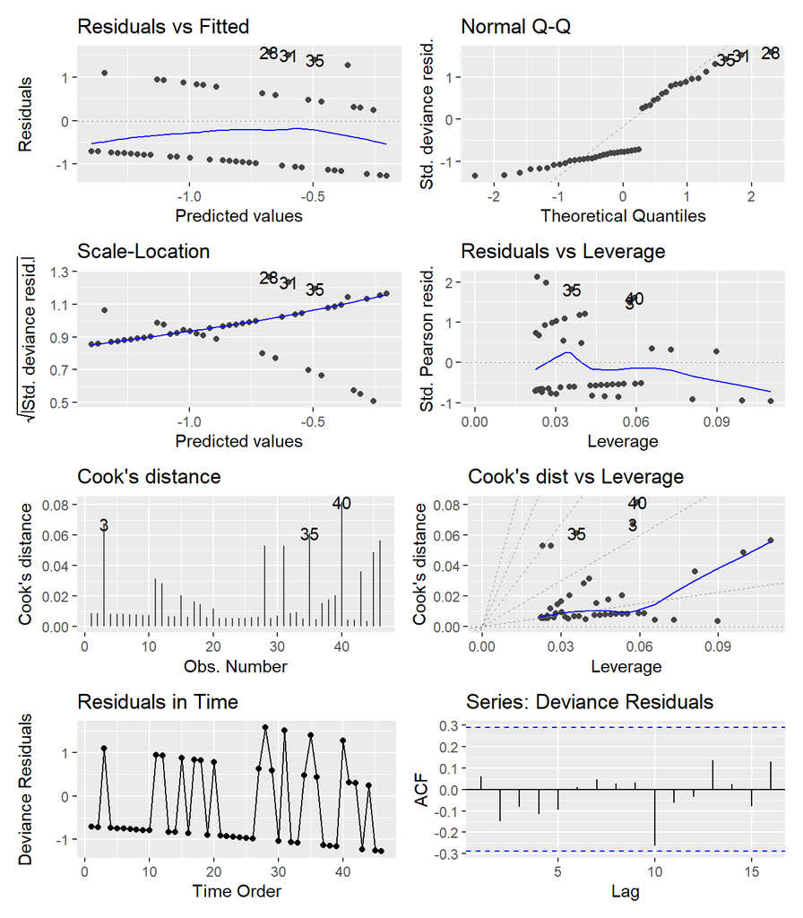

#### Logistic Regression on Proportions of Major

```
Call:  glm(formula = cbind(Major_Storms, Non_Major) ~ YearsSinceStart,
    family = binomial, data = prop_data)

Coefficients:
    (Intercept)  YearsSinceStart
       -1.36063          0.03862

Degrees of Freedom: 37 Total (i.e. Null);  36 Residual
Null Deviance:      68.62
Residual Deviance: 64.21    AIC: 87.67
```

```
Single term deletions

Model:
cbind(Major_Storms, Non_Major) ~ YearsSinceStart
                Df Deviance    AIC    LRT Pr(>Chi)
<none>               64.212 87.666
YearsSinceStart  1   68.624 90.078 4.4116   0.0357 *
---
Signif. codes:  0 '***' 0.001 '**' 0.01 '*' 0.05 '.' 0.1 ' ' 1
```

Using this model, in 1980 the probability of a major storm in was 0.2041382 (CI: 0.0812847, 0.4264774) and in 2025 the probability of a major storm was 0.5932602 (CI: 0.3889231, 0.7697251).

That is a change of 8.4591733 percent per decade.

**Model Assessment**

The ratio of the residual deviance is 1.7836683.

The $p$-value for the Ljung-Box test on the deviance residuals 0.5251242.

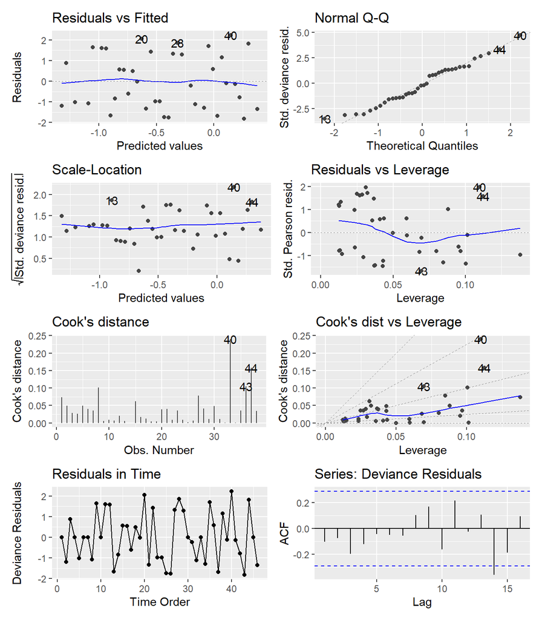

#### Logistic Regression on Proportions of Intense

```
Call:  glm(formula = cbind(Intense_Storms, Non_Intense) ~ YearsSinceStart,
    family = binomial, data = prop_data)

Coefficients:
    (Intercept)  YearsSinceStart
       -1.56525          0.01942

Degrees of Freedom: 37 Total (i.e. Null);  36 Residual
Null Deviance:      50.2
Residual Deviance: 49.29    AIC: 72.75
```

```
Single term deletions

Model:
cbind(Intense_Storms, Non_Intense) ~ YearsSinceStart
                Df Deviance    AIC     LRT Pr(>Chi)
<none>               49.291 72.745
YearsSinceStart  1   50.201 71.655 0.90992   0.3401
```

That is a change of 3.4956567 percent per decade.

**Model Assessment**

The ratio of the residual deviance is 1.3692048.

The $p$-value for the Ljung-Box test on the deviance residuals 0.4488092.

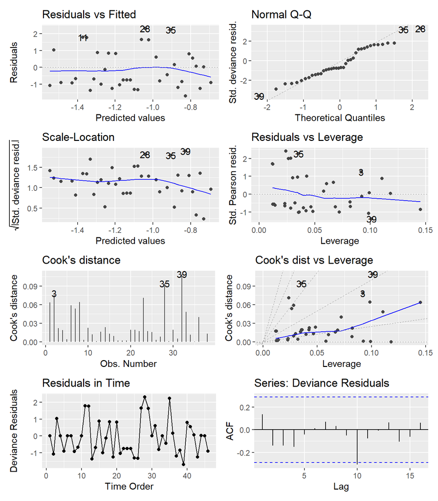

## HURSAT Quick Results

### Summary Statistics and Data

| Total Storms (Avg) | Total Storms (stddev) | Hurricanes (Avg) | Hurricanes (stddev) | Major Storms (Avg) | Major Storms (stddev) | Prop Major Storms | Intense Storms (Avg) | Intense Storms (stddev) | Prop Intense Storms |
| --- | --- | --- | --- | --- | --- | --- | --- | --- | --- |
| 1.954546 | 1.238051 | 1.136364 | 0.9545706 | 0.5681818 | 0.7280981 | 0.2906977 | 0.2727273 | 0.5440433 | 0.1395349 |

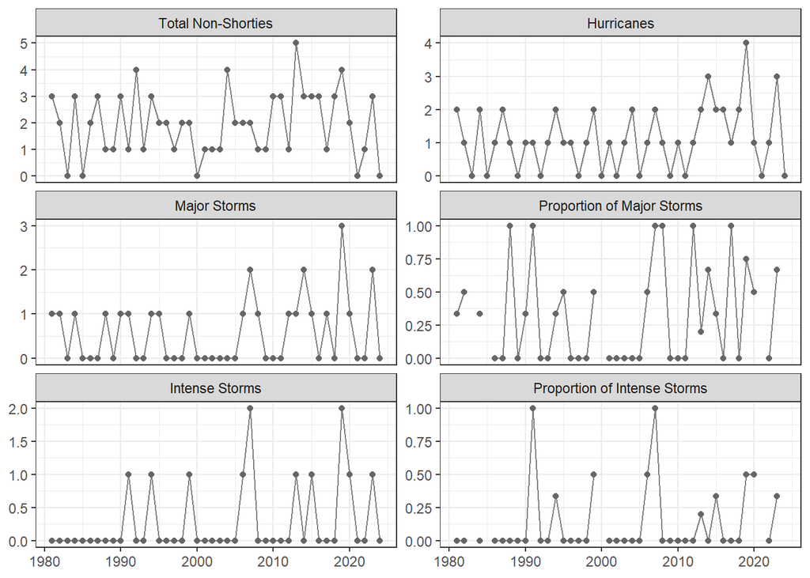

### Testing Results

**Changepoint Methods**

Here, we report the estimate mean for each segment or regime regardless of whether the test found a significant shift.

| Response | Chpt.Location | p.value | Regime1 | Regime2 | Change | Perc_Change |
| --- | --- | --- | --- | --- | --- | --- |
| Cyclone Freq | 2004 | 0.61064 | 1.69565 | 2.23810 | 0.54244 | 31.99023 |
| Hurricanes | 2013 | 0.20833 | 0.90625 | 1.75000 | 0.84375 | 93.10345 |
| Major Freq | 2006 | 0.22582 | 0.36000 | 0.84211 | 0.48211 | 133.91813 |
| Prop Major | 2006 | 0.47984 | 20.00000 | 39.02439 | 19.02439 | 95.12195 |
| Intense Freq | 2006 | 0.09050 | 0.12000 | 0.47368 | 0.35368 | 294.73684 |
| Prop Freq | 1991 | 0.57942 | 0.00000 | 17.64706 | 17.64706 | Inf |

**Generalized Linear Model Approaches**

Note:

- we report the Likelihood Ratio Test for the generalized linear models, this is better to use than the default $Z$-test provided in the `summary()` output.
- the Change per decade is found by comparing the predicted value at the start time (1981) and end time (2024) and scaling by the number of years $\times 10$.

| Response | Coefficent | p.value | Start | End | Change per Decade |
| --- | --- | --- | --- | --- | --- |
| Cyclone Freq | 0.00426 | 0.61631 | 1.78099 | 2.13875 | 0.08131 |
| Hurricanes | 0.01448 | 0.19565 | 0.81836 | 1.52561 | 0.16074 |
| Major Freq | 0.01946 | 0.22084 | 0.36276 | 0.83753 | 0.10790 |
| Prop Major | 0.02237 | 0.24756 | 19.70631 | 39.10891 | 4.40968 |
| Intense Freq | 0.04571 | 0.05530 | 0.08672 | 0.61898 | 0.12097 |
| Prop Freq | 0.05202 | 0.05447 | 4.23577 | 29.28842 | 5.69378 |

## HURSAT Full Analysis

### Changepoint Methods

#### Change in Non-Shorty Counts

```
  SCUSUM Stat chpt Location       p-value
   0.08861474   23.00000000    0.61063758
```

The dates suggest the changepoint would occur from 2003 to 2004 with $p$-value 0.6106376.

In regime one, the mean number of storms is 1.6956522 (CI: 1.2388905, 2.3208154) and in regime two, the mean number of storms is 2.2380952 (CI: 1.6815732, 2.9788); a change of 0.5424431.

**Model Assessment**

The ratio of the residual deviance is 0.9350807.

The $p$-value for the Ljung-Box test on the deviance residuals 0.5422965.

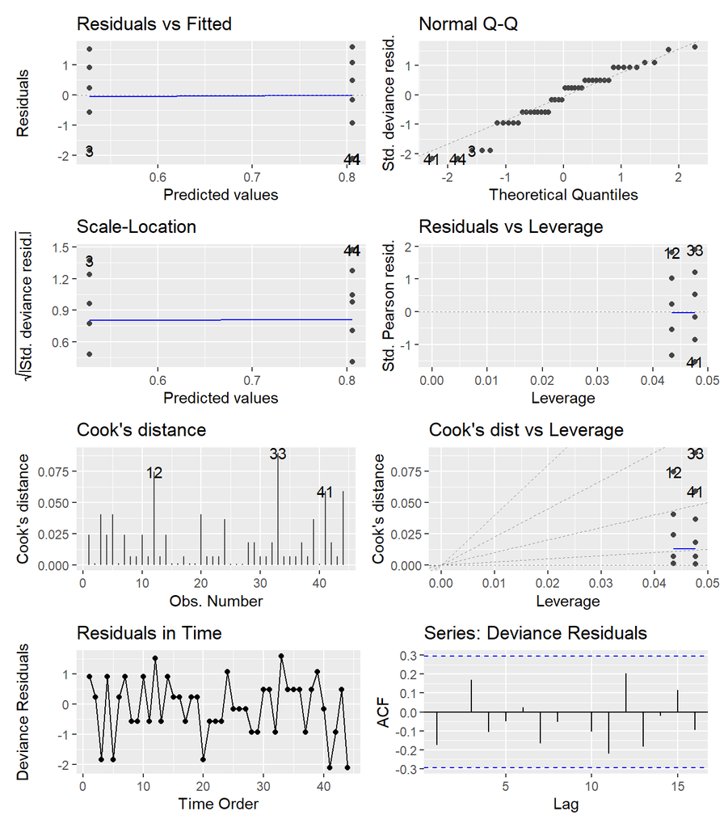

#### Change in counts of hurricanes

```
  SCUSUM Stat chpt Location       p-value
    0.2505992    32.0000000     0.2083252
```

The dates suggest the changepoint would occur from 2012 to 2013 with $p$-value 0.2083252.

In regime one, the mean number of hurricanes is 0.90625 (CI: 0.6297686, 1.3041125) and in regime two, the mean number of hurricanes is 1.75 (CI: 1.1410042, 2.6840392); a change of 0.84375.

**Model Assessment**

The ratio of the residual deviance is 0.8804247.

The $p$-value for the Ljung-Box test on the deviance residuals 0.1662491.

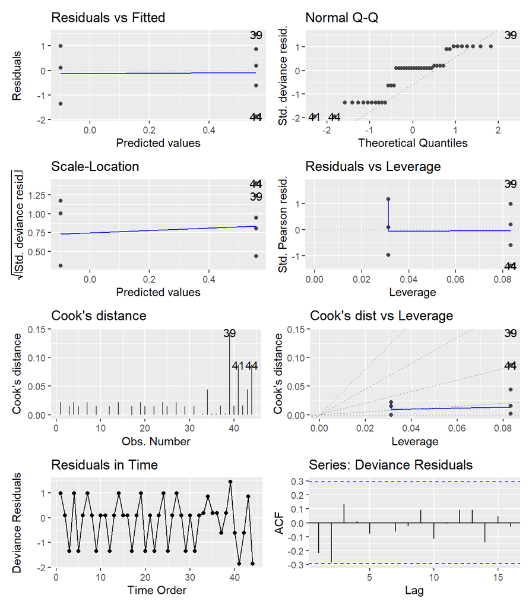

#### Change in counts of major storms

```
  SCUSUM Stat chpt Location       p-value
    0.2390393    25.0000000     0.2258249
```

The dates suggest the changepoint would occur from 2005 to 2006 with $p$-value 0.2258249.

In regime one, the mean number of storms is 0.36 (CI: 0.1873133, 0.6918889) and in regime two, the mean number of storms is 0.8421053 (CI: 0.515897, 1.3745793); a change of 0.4821053.

**Model Assessment**

The ratio of the residual deviance is 0.9237707.

The $p$-value for the Ljung-Box test on the deviance residuals 0.5278572.

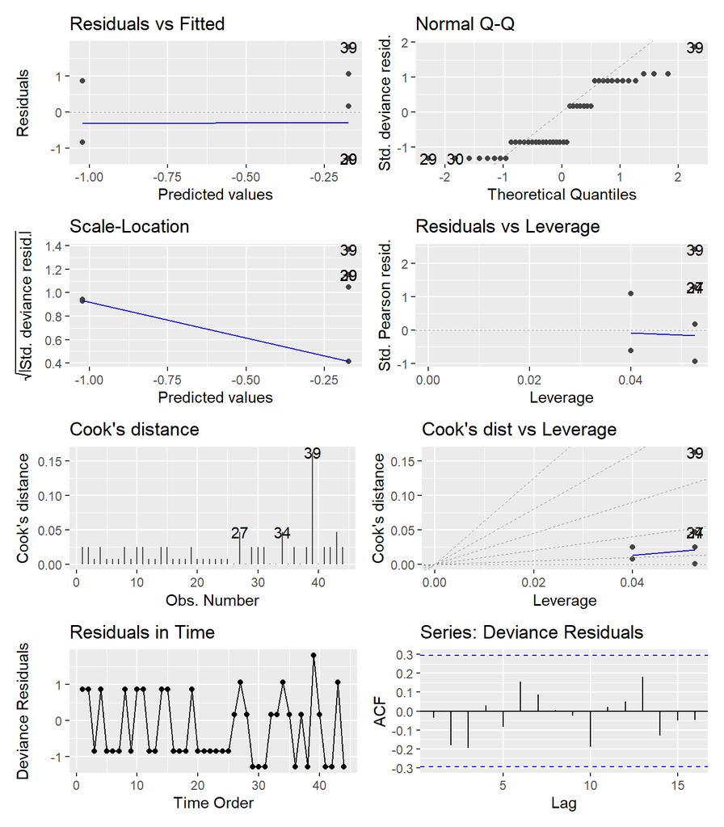

#### Change in counts of intense storms

```
  SCUSUM Stat chpt Location       p-value
   0.37792700   25.00000000    0.09049909
```

The dates suggest the changepoint would occur from 2005 to 2006 with $p$-value 0.0904991.

In regime one, the mean number of storms is 0.12 (CI: 0.0387018, 0.372076) and in regime two, the mean number of storms is 0.4736842 (CI: 0.2464619, 0.910391); a change of 0.3536842.

**Model Assessment**

The ratio of the residual deviance is 0.7551576.

The $p$-value for the Ljung-Box test on the deviance residuals 0.6780685.

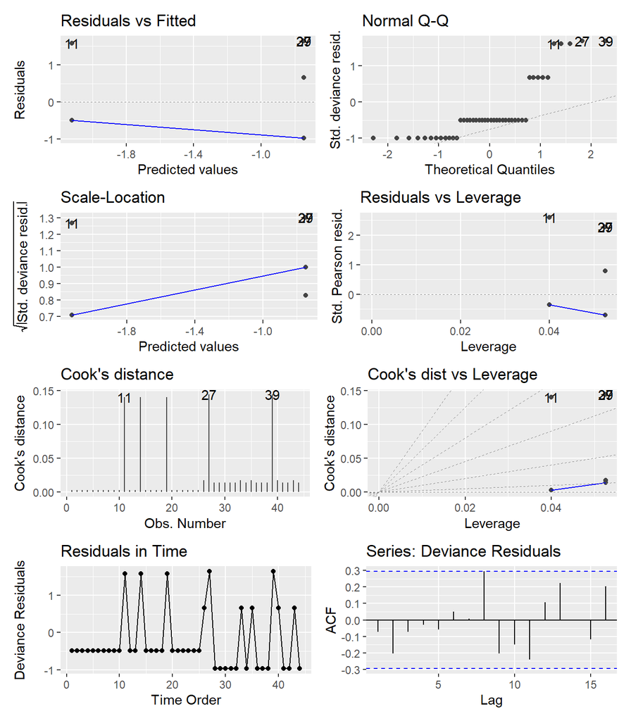

#### Proportion of major storms

A change in the proportion of major storms?

```
  SCUSUM Stat chpt Location       p-value
    0.1402978    25.0000000     0.4798433
```

The change in proportions occurs 2005 to 2006 with $p$-value 0.4798433.

In regime one, the proportion of major storms is 0.2 (CI: 0.1074801, 0.3416734) and in regime two, the proportion of major storms is 0.3902439 (CI: 0.2546824, 0.5451812); a change of 0.1902439.

**Model Assessment**

The ratio of the residual deviance is 1.3454933.

The $p$-value for the Ljung-Box test on the deviance residuals 0.4499723.

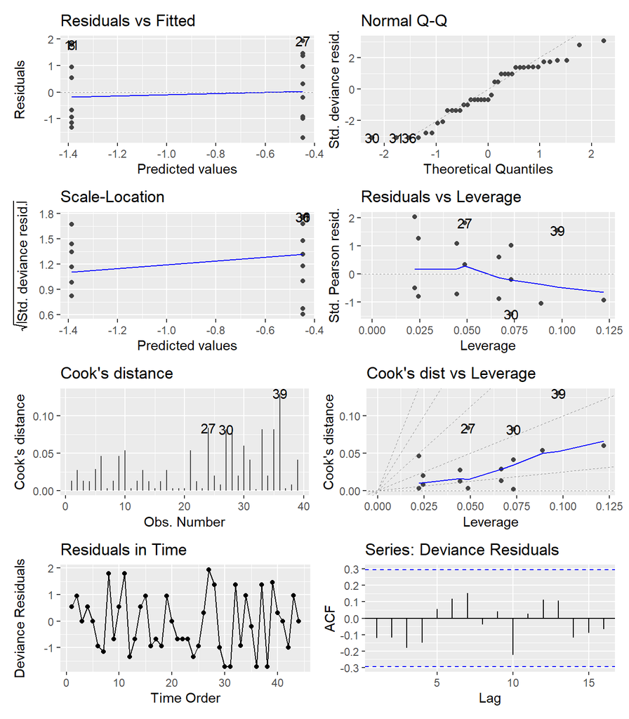

#### Proportion of intense storms

A change in the proportion of intense storms?

```
  SCUSUM Stat chpt Location       p-value
    0.1188748    10.0000000     0.5794190
```

The change in proportions occurs 1990 to 1991 with $p$-value 0.579419.

In regime one, the proportion of intense storms is 2.0734492^{-9} (CI: 0, 1) and in regime two, the proportion of intense storms is 0.1764706 (CI: 0.1030367, 0.2855777); a change of 0.1764706.

**Model Assessment**

The ratio of the residual deviance is 0.8932885.

The $p$-value for the Ljung-Box test on the deviance residuals 0.5509804.

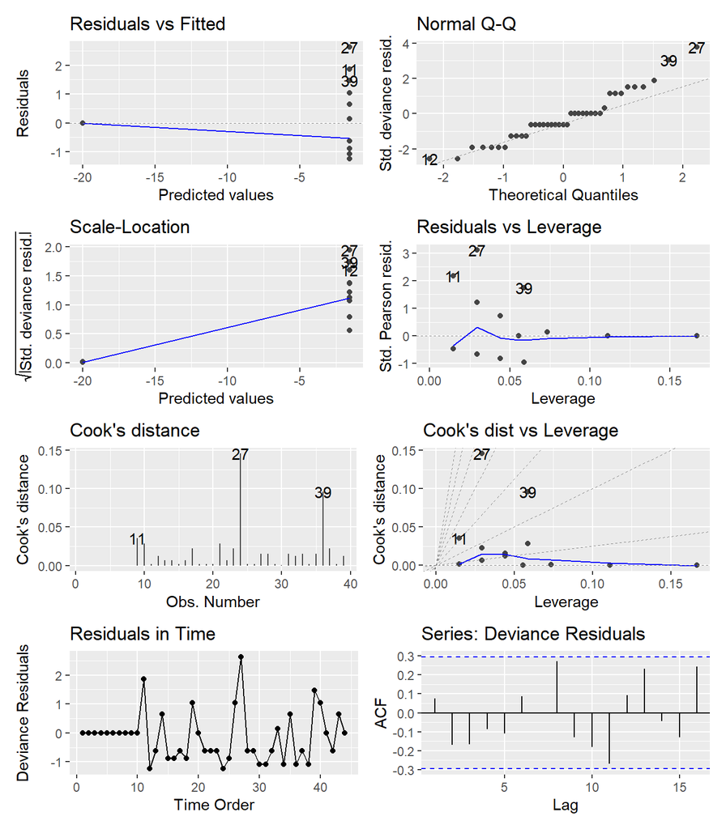

### Regression Methods

#### Poisson Regression on non-Shorties

```
Call:  glm(formula = Total_Storms ~ YearsSinceStart, family = poisson(link = "log"),
    data = storm_basin)

Coefficients:
    (Intercept)  YearsSinceStart
       0.577171         0.004257

Degrees of Freedom: 43 Total (i.e. Null);  42 Residual
Null Deviance:      40.92
Residual Deviance: 40.67    AIC: 146
```

```
Single term deletions

Model:
Total_Storms ~ YearsSinceStart
                Df Deviance    AIC     LRT Pr(>Chi)
<none>               40.673 145.99
YearsSinceStart  1   40.924 144.24 0.25109   0.6163
```

Using this model, in 1981 we would predict 1.7809922 storms (CI: 1.1634832, 2.7262388) and in 2024 we predict 2.1387538 storms (CI: 1.4249751, 3.2100688).

That is a change of 0.0813095 storms per decade.

**Model Assessment**

The ratio of the residual deviance is 0.9684097.

The $p$-value for the Ljung-Box test on the deviance residuals 0.608887.

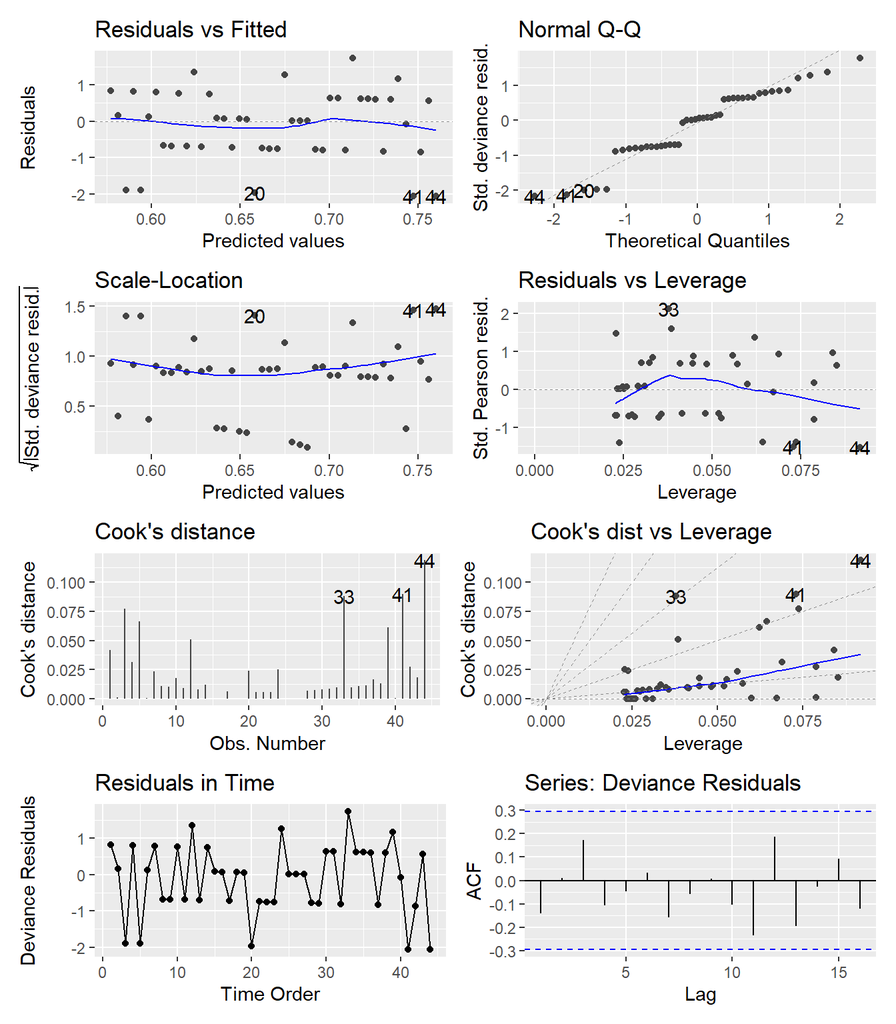

#### Poisson Regression on Hurricanes

```
Call:  glm(formula = Hurricanes ~ YearsSinceStart, family = poisson(link = "log"),
    data = storm_basin)

Coefficients:
    (Intercept)  YearsSinceStart
       -0.20045          0.01448

Degrees of Freedom: 43 Total (i.e. Null);  42 Residual
Null Deviance:      41.99
Residual Deviance: 40.31    AIC: 118.3
```

```
Single term deletions

Model:
Hurricanes ~ YearsSinceStart
                Df Deviance    AIC    LRT Pr(>Chi)
<none>               40.314 118.31
YearsSinceStart  1   41.989 117.99 1.6746   0.1956
```

Using this model, in 1981 we would predict 0.818364 hurricanes (CI: 0.451883, 1.4820643) and in 2024 we predict 1.5256141 hurricanes (CI: 0.9201096, 2.5295879).

That is a change of 0.1607386 hurricanes per decade.

**Model Assessment**

The ratio of the residual deviance is 0.9598634.

The $p$-value for the Ljung-Box test on the deviance residuals 0.4088948.

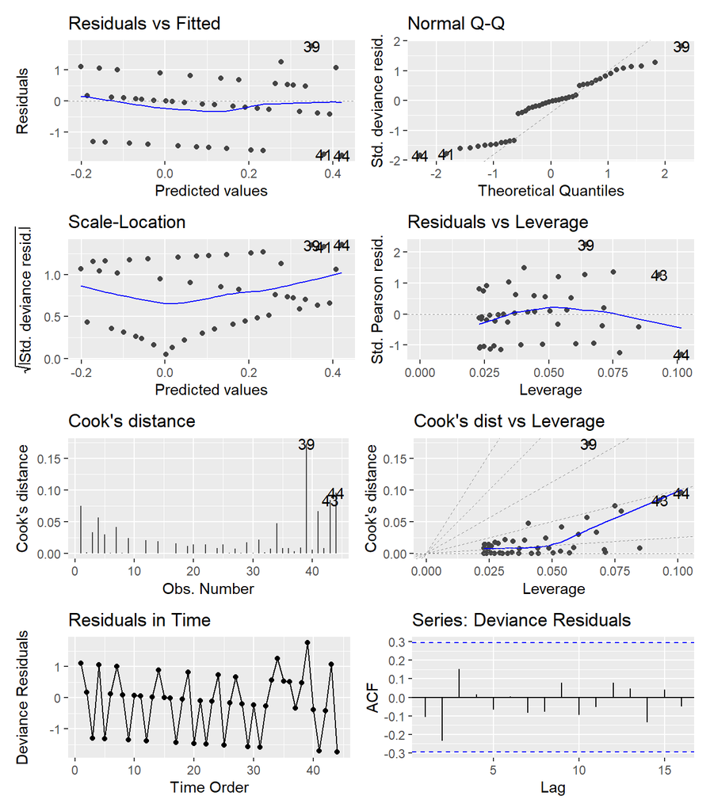